# 20.14 Две проверки моделей с литературными сопротивлениями

**Утверждённая автором программа от 10.09.2026:** проверить геометрические упрощения на синтетических данных с заданными сопротивлениями и сопоставить модели по экспериментальным импедансам, когда сопротивления неизвестны. КТ принимается как физически достоверный источник анатомии. Материалов два: лёгкое с $\rho_2$ и нелёгочный фон с $\rho_1$, включая поддиафрагмальные ткани. По решению автора литературные ориентиры для $\rho_1$ берутся по мягким тканям и мышцам, для $\rho_2$ — по лёгким.

Ноутбук продолжает 20.13 — геометрические упрощения. Предыдущие расчёты сохранены. Здесь выполнены новые прямые КТ/FEM-расчёты независимо от интерполяции библиотеки и инверсия с ограничениями на оба сопротивления. FEM обозначает метод конечных элементов; PEM — модель точечных электродов; CEM — полную модель конечных эквипотенциальных электродов с сопротивлением контакта. Карта проекта.

## 1. Входные данные и проверяемые утверждения

Геометрия, сетка, четыре варианта лёгочной области и электродные условия перенесены из 20.13. В пространственной группе сохраняются наружная КТ-поверхность, сетка и точечные контакты вблизи центроидов конечных площадок. Меняется внутренняя материальная маска: исходная КТ, плоская граница, эллипсоид по объёмным моментам или эллипсоид с привязкой по центральной глубине. Аналитические приближения используют номинальные точки на плоскости; сравнение с ними охватывает совокупность геометрических и электродных упрощений.

**Физическая постановка.** В объёме решается стационарная задача проводимости $\nabla\!\cdot(\sigma\nabla u)=0$, где $u$ — потенциал, $\sigma=1/\rho$. На границе тканей непрерывны потенциал и нормальный ток; наружная поверхность вне электродов изолирована. Для заданного тока $I$ измеряется передаточный импеданс $Z=(U_{V+}-U_{V-})/I$. Линейность позволяет рассчитывать его при единичном токе, не принимая 1 А за реальный ток прибора. Используются два постоянных действительных скалярных сопротивления; пространственная неоднородность возникает за счёт формы областей.

**Пространственная модель** задаёт материальную маску во всём трёхмерном теле и численно рассчитывает перераспределение тока. Плоской здесь может быть только заменённая внутренняя граница: наружная КТ-поверхность остаётся кривой, а тело — конечным. **Плоская аналитическая модель** одновременно заменяет наружную поверхность и межтканевые границы параллельными плоскостями, продолжает слои в стороны до бесконечности и использует слоистую функцию Грина. Это разные физические области, а не два способа решения одной и той же геометрической задачи. При усреднении глубин или ядер формула остаётся приближением: боковое перераспределение тока возле кривой поверхности и края лёгкого явно не решается.

| Модель в таблицах | Что сохранено или заменено |
| --- | --- |
| КТ: исходная граница лёгкого | Полная исходная двухтканная маска; численный контроль синтетической инверсии |
| Плоская граница в объёме тела | Ближняя область заменена полупространством внутри КТ-тела с глубиной входа центрального луча |
| Эллипсоид по объёму и моментам | Ориентация и отношения осей заданы объёмными моментами, непрерывный объём согласован до отсечения телом |
| Эллипсоид с привязкой по глубине | Тот же эллипсоид сдвинут до совпадения первого пересечения центрального луча с КТ |
| Аналитика: постоянная глубина | Прежняя двуслойная формула с одной глубиной 30,4296 мм |
| Аналитика: средняя глубина по паре | Для каждой токово-потенциальной пары подставлено среднее значение полиномиального профиля глубины |
| Аналитика: среднее двухслойное ядро | Усредняется сама функция Грина вдоль пары при переменной глубине; это отличается от подстановки среднего h |
| Аналитика: конечная толщина лёгкого | По паре усредняются глубина входа и толщина лёгочного интервала; используются три геометрических слоя ρ₁–ρ₂–ρ₁ |

Здесь $h$ — глубина ближней поверхности лёгкого вдоль принятого направления отсчёта; конкретные определения глубины различаются между строками таблицы. В последней строке **три слоя содержат только два материала**: нижний фон, включая область под диафрагмой, имеет то же $\rho_1$, что грудная стенка. В пространственных заменах сохраняется дальняя часть исходной лёгочной маски. Разделение на ближнюю и дальнюю части — геометрическое по глубине, а не новая анатомическая сегментация. Эти варианты проверяют конкретное сокращение информации; они пока не исключают КТ из исходных данных. Быстрая интерполяция библиотеки пространственных откликов ускоряет инверсию, но сама библиотека построена с помощью FEM. Её использование не является отдельным доказательством возможности рассчитывать произвольную кривую геометрию аналитически.

Экспериментальный вход — девять уровней импеданса на задержке вдоха у Ника в эксперименте 2 на реокардиомониторе МГТУ. Размеры: 50, 60, 70, 80, 90, 110, 120, 130 и 140 мм. Поздняя копия 100 мм исключена по субъектному манифесту. Используются сохранённые уровни; сырые сигналы и дыхательная разметка здесь заново не обрабатываются. Последовательно записанные сборки считаются сопоставимыми по состоянию испытуемого — это принятое допущение.

| Проверка | Наблюдения | Известны ли сопротивления? | Что можно оценить |
| --- | --- | --- | --- |
| Синтетическая | Независимое решение поля на исходной КТ-геометрии | Заданы только для данного опыта | Смещение обоих параметров при замене модели |
| Экспериментальная | Измеренные импедансы на вдохе | Неизвестны | Остаток, условный прогноз исключённых размеров, устойчивость и влияние границ |

### 1.1. Какие электроды использованы

В каждой сборке четыре электрода: $I+$ и $I-$ задают ток, $V+$ и $V-$ задают измеряемую разность потенциалов. Девять размеров соответствуют девяти отдельным расчётным монтажам. В каждом монтаже активна своя четвёрка; 36 площадок не рассматриваются как одновременно подключённая система.

| Постановка | Представление электрода | Как вводится ток и определяется напряжение | Что из свойств контакта учитывается |
| --- | --- | --- | --- |
| Пространственная PEM | Один узел сетки вблизи центроида каждой площадки на КТ-поверхности | Ток задаётся в токовых узлах; напряжение — разность потенциалов измерительных узлов | Положение точки; конечная площадь, эквипотенциальность площадки и поверхностное сопротивление контакта отсутствуют в операторе |
| Аналитическая точечная | Номинальная точка на плоской поверхности слоистой среды | Используется отклик точечного источника и разность потенциалов точечных приёмников | Номинальная геометрия точек; площадь и контактный параметр отсутствуют |
| Пространственная CEM | Проводящая площадка из граничных треугольников сетки | Ток распределяется по площадке; напряжение определяется потенциалами металлических электродов | Конечная площадь, единый потенциал каждого электрода и заданное сопротивление контакта |

Слово «конечный» относится к **размеру контактной площадки**. Оно не означает дополнительный тканевый слой или только два крайних электрода: в CEM все четыре электрода имеют ненулевую площадь. «Пространственная» и «аналитическая» характеризуют геометрию и способ расчёта поля, а PEM и CEM — электродные граничные условия. Само наличие FEM не означает, что электроды конечные.

### 1.2. Реестр выполненных расчётов 20.14

| Расчёт | Какая геометрия | Какие электроды | Объём выполненной проверки | Где находится результат |
| --- | --- | --- | --- | --- |
| Генерация синтетических наблюдений | Только исходная КТ-маска | Пространственная PEM | 49 заданных пар сопротивлений × 9 размеров = 441 импеданс | Раздел 4; синтетический эталон |
| Восстановление синтетических сопротивлений | КТ, плоская внутренняя граница, два эллипсоида | Пространственная PEM | 49 × 4 = 196 инверсий | Раздел 4, таблицы ошибок и рисунок 2 |
| Восстановление синтетических сопротивлений | Четыре слоистых приближения | Аналитические точечные электроды | 49 × 4 = 196 инверсий | Раздел 4, те же таблицы |
| Основная подгонка измерений | Четыре пространственные и четыре аналитические модели | PEM для пространственных; номинальные точки для аналитических | 8 подгонок по 9 уровням вдоха | Раздел 5, рисунок 3 |
| Исключение размеров | Те же восемь моделей | Те же точечные постановки | 8 × 9 = 72 подгонки с прогнозом исключённого размера | Раздел 6, рисунок 4 |
| Возмущения ±1% | Те же восемь моделей | Те же точечные постановки | 8 × 18 = 144 подгонки | Раздел 6, таблица сдвигов параметров |
| Узкий лёгочный диапазон и плотность поиска | Те же восемь моделей | Те же точечные постановки | По 8 повторных подгонок для каждой проверки | Разделы 3 и 6 |
| Дополнительная подгонка измерений | Только исходная КТ-маска | CEM для всех четырёх электродов | 3 начальных приближения; один и тот же ряд из 9 измерений | Раздел 7, рисунок 5 |
| Проверка производных CEM | Только исходная КТ-маска | CEM | 2 размера × 2 параметра × 2 шага = 8 сравнений с конечными разностями | Раздел 9 |

**Граница выполненного плана:** в 20.14 синтетические наблюдения для 49 пар не пересчитывались с CEM. Для плоской внутренней границы и обоих эллипсоидов новая CEM-инверсия также не выполнялась. Исключения размеров, возмущения ±1% и проверка узкой области из раздела 6 относятся к точечным постановкам. Ранее выполненные отдельные CEM-опыты 20.13 сохраняют собственный состав проверок и не превращают эти новые тесты в CEM-тесты.

**Ограничение разделения данных.** Поза электродов получена ранее с использованием всего размерного ряда. В нынешних исключениях размера заново подбираются только сопротивления. Поэтому проверочный импеданс исключён из этой подгонки, но его влияние на прежний выбор позы сохраняется. Результат является условной проверкой при фиксированной позе и не подтверждает независимый прогноз всей методики.

| Размер, мм | Измеренный импеданс на вдохе, Ом |
| --- | --- |
| 50 | 85,689 |
| 60 | 101,1 |
| 70 | 88,678 |
| 80 | 83,943 |
| 90 | 74,58 |
| 110 | 65,581 |
| 120 | 62,821 |
| 130 | 60,923 |
| 140 | 50,103 |

## 2. Литературная область сопротивлений

Численный источник — [IT’IS Tissue Properties Database V5.0](https://itis.swiss/virtual-population/tissue-properties/downloads/database-v5-0), опубликованная 21.08.2025. Использована уже сохранённая в проекте исходная таблица с коэффициентами и её контрольной суммой. Метаданные тематических коллекций, затем всей резервной библиотеки Zotero проверены; поиск по названиям не выявил отдельных работ, посвящённых проводимости рассматриваемых тканей. Локальный API Zotero был недоступен; отсутствие найденного названия не означает отсутствия сведений внутри других работ. Новые записи в библиотеку не добавлялись.

В базе различаются [частотная модель Gabriel](https://itis.swiss/virtual-population/tissue-properties/database/dielectric-properties) и [сводка низкочастотной проводимости до 1 МГц](https://itis.swiss/virtual-population/tissue-properties/database/low-frequency-conductivity). Первая даёт значение на выбранной частоте; вторая объединяет литературный разброс, в том числе разные направления измерения. Она не является популяционным интервалом нормы на частоте 50 кГц.

**Расчётная операция:** в действительной скалярной модели $\rho=1/\sigma$, где $\sigma$ выражена в См/м, $\rho$ — в Ом·м. Поэтому диапазон проводимости $[\sigma_{\min},\sigma_{\max}]$ переходит в диапазон сопротивления $[1/\sigma_{\max},1/\sigma_{\min}]$. Диэлектрическая часть и анизотропия в электрическом решателе этого опыта не добавляются; литературный разброс не заменяет их явное моделирование.

Для $\rho_1$ принят диапазон **1,3774–10,0000 Ом·м**, полученный из смешанного по направлениям низкочастотного диапазона мышцы 0,100–0,726 См/м. Для $\rho_2$ на вдохе принят диапазон **9,7413–24,0741 Ом·м**: объединены частотный ориентир наполненного воздухом лёгкого при 50 кГц и его низкочастотный литературный диапазон 14,2857–24,0741 Ом·м. Объединение этих ориентиров и перенос мышечного диапазона на весь нелёгочный фон являются **явными допущениями настоящего плана**. Диапазоны задают рабочую область, основанную на литературе; они не подтверждают нормальность каждого сочетания у данного испытуемого.

Ненаполненное лёгкое приведено для различения литературных состояний, но не задаёт основной диапазон вдоха. Его нельзя приравнять к обычному выдоху исследуемого добровольца. Жировой ориентир в исходной таблице сохранён для происхождения данных и не расширяет мышечные границы основного опыта по последнему указанию автора.

| Ткань | σ при 50 кГц, См/м | ρ при 50 кГц, Ом·м | НЧ: нижний ρ, Ом·м | НЧ: верхний ρ, Ом·м |
| --- | --- | --- | --- | --- |
| Лёгкое, ненаполненное | 0,26197 | 3,8173 | 4,9618 | 23,9 |
| Лёгкое, наполненное воздухом | 0,10266 | 9,7413 | 14,286 | 24,074 |
| Мышца | 0,35183 | 2,8423 | 1,3774 | 10 |

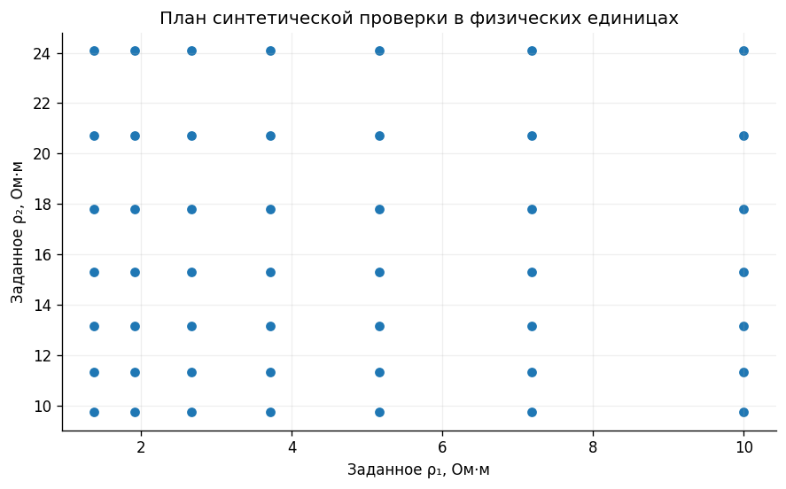

**Рисунок 1. Сочетания сопротивлений для синтетического теста.** Каждая точка задаёт одну пару, при которой заново решена прямая задача на исходной КТ-геометрии. Семь уровней каждого сопротивления равномерны по логарифму, поэтому в линейных координатах расстояния между ними различаются. По рисунку следует проверять охват области и наличие граничных случаев. Все 49 сочетаний одинаково учитываются в табличных сводках; эти веса относятся к плану вычислений и не задают распределение сопротивлений в популяции. Геометрия на вдохе фиксирована во всех точках. Следующий шаг — сравнить восстановленные параметры с координатами соответствующих заданных точек.

## 3. Ограниченная обратная задача

Для фиксированной геометрии и точечных контактов используется свойство $Z_L=\rho_1 f_L(q)$, где $q=\rho_2/\rho_1$ — контраст, $L$ — размер, $f_L$ — нормированный отклик, м⁻¹. При каждом $q$ сначала определяется допустимый интервал масштаба:

$$\ell(q)=\max(\rho_{1,\min},\rho_{2,\min}/q),\qquad u(q)=\min(\rho_{1,\max},\rho_{2,\max}/q),$$ где $\ell,u$ и все $\rho$ имеют размерность Ом·м. При $\ell>u$ контраст недопустим. В остальных случаях масштаб наименьших квадратов ограничивается интервалом $[\ell,u]$ **до** сравнения остатков разных контрастов. Используются одинаковые веса размеров; распределение измерительной ошибки этим не устанавливается. Поиск рассматривает разрешённые сеткой локальные минимумы и границы. Повторная сетка из 1601 точки проверяет устойчивость результата основного поиска по 401 точке, но не доказывает глобальную единственность.

Для CEM контактное сопротивление фиксировано и простое масштабирование не применяется. Безразмерные координаты оптимизации определяются как $x_j=\ln(\rho_j/\rho_0)$, где $\rho_0=1$ Ом·м. Дополнительная CEM-подгонка в разделе 7 решает поле напрямую и одновременно оптимизирует логарифмы обоих сопротивлений внутри тех же границ.

## 4. Синтетическая проверка ошибки сокращения геометрии

Для 49 заданных пар исходная КТ/FEM-модель **с точечными электродами PEM** формирует девять импедансов. Это отдельные прямые решения; значения не получены интерполяцией библиотеки инверсии. Каждый из восьми способов восстанавливает два сопротивления по всему ряду. Известный вход сравнивается с оценкой:

$$e_j=100(\widehat\rho_j/\rho_j^*-1)\%,\qquad j=1,2,$$ где $\rho_j^*$ — заданное значение, $\widehat\rho_j$ — результат инверсии. Ошибки всех моделей отсчитываются от заданных сопротивлений исходной КТ-задачи. Прежняя аналитическая формула служит рубежом для оценки улучшения; её собственная ошибка также рассчитывается и не принимается равной нулю. Медиана и максимум $|e_j|$ характеризуют данный план из 49 случаев. Они не являются ожидаемой ошибкой или доверительной границей для популяции. При подсчёте улучшений обоих параметров по сравнению с прежней формулой требуется уменьшение каждой абсолютной ошибки более чем на 0,001 процентного пункта. Это порог отделения численного округления, а не клинический допуск.

В план входят 24 граничных и 25 внутренних сочетаний. Ограничения могут уменьшать ошибку за счёт известной границы поиска; такой эффект нельзя полностью приписывать точности геометрии. Поэтому приведена отдельная сводка внутренних случаев. Выход оценки на границу при истинно граничном входе сам по себе не является дефектом модели.

| Модель | Медиана \|e₁\|, % | Макс. \|e₁\|, % | Медиана \|e₂\|, % | Макс. \|e₂\|, % | Оба параметра лучше прежних, из 49 |
| --- | --- | --- | --- | --- | --- |
| КТ: исходная граница лёгкого | 2,9066e-07 | 8,9602e-06 | 5,0906e-05 | 0,00026799 | 42 |
| Плоская граница в объёме тела | 1,7392 | 12,666 | 32,406 | 59,536 | 7 |
| Эллипсоид по объёму и моментам | 0,80873 | 3,6676 | 21,196 | 147,13 | 12 |
| Эллипсоид с привязкой по глубине | 0,30349 | 2,5139 | 16,276 | 112,54 | 15 |
| Аналитика: постоянная глубина | 0,48129 | 2,2039 | 26,036 | 96,325 | 0 |
| Аналитика: средняя глубина по паре | 0,46786 | 2,2718 | 27,168 | 97,569 | 12 |
| Аналитика: среднее двухслойное ядро | 0,51882 | 2,1907 | 26,036 | 96,93 | 20 |
| Аналитика: конечная толщина лёгкого | 1,4736 | 3,4161 | 35,2 | 130,73 | 5 |

**Только 25 внутренних сочетаний:**

| Модель | Медиана \|e₁\|, % | Макс. \|e₁\|, % | Медиана \|e₂\|, % | Макс. \|e₂\|, % |
| --- | --- | --- | --- | --- |
| КТ: исходная граница лёгкого | 5,9736e-07 | 1,8173e-06 | 8,3704e-05 | 0,00024544 |
| Плоская граница в объёме тела | 3,9489 | 11,985 | 36,389 | 52,95 |
| Эллипсоид по объёму и моментам | 0,80873 | 3,0171 | 35,2 | 112,54 |
| Эллипсоид с привязкой по глубине | 0,30068 | 1,9164 | 22,003 | 82,791 |
| Аналитика: постоянная глубина | 0,38801 | 1,5718 | 20,523 | 69,103 |
| Аналитика: средняя глубина по паре | 0,46786 | 1,6184 | 20,076 | 68,738 |
| Аналитика: среднее двухслойное ядро | 0,47477 | 1,5025 | 21,006 | 68,501 |
| Аналитика: конечная толщина лёгкого | 1,8531 | 3,3038 | 57,205 | 112,54 |

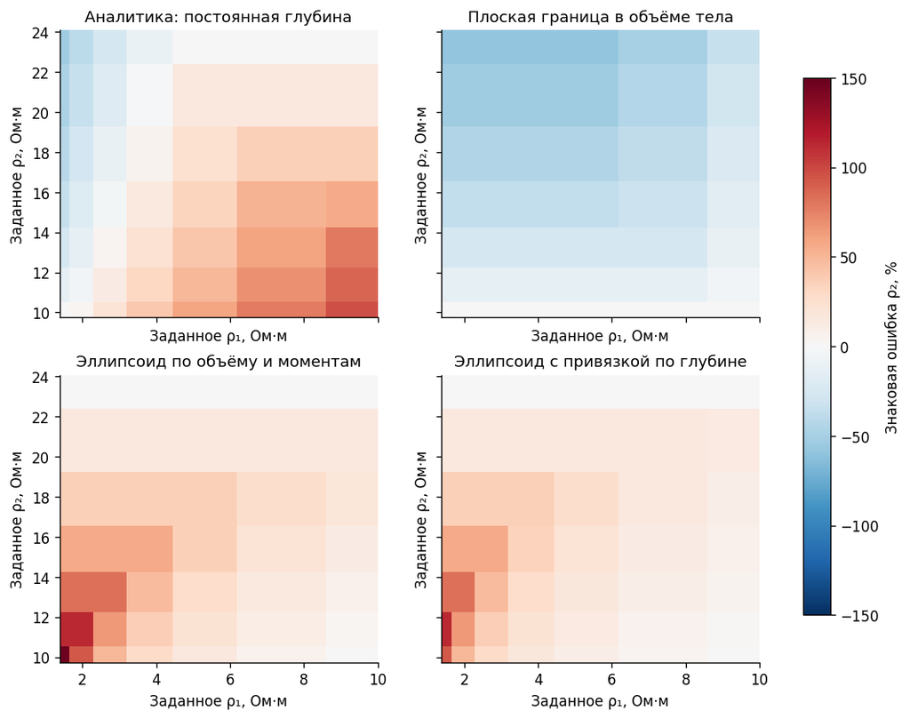

Максимальное расхождение интерполяции исходного оператора с 49 независимыми прямыми расчётами: **3.46e-05 Ом**.

**Рисунок 2. Ошибка восстановления лёгочного сопротивления.** Панели показывают четыре сокращённых описания; координаты — заданные сопротивления. Исходные синтетические данные рассчитаны с PEM; три пространственных сокращения также используют PEM, а прежняя аналитика — номинальные точки на плоскости. Конечные площадки CEM в этот рисунок не входят. Красный цвет означает завышение $\rho_2$, синий — занижение, белый — близость к заданному значению. Шкала общая. Следует сравнивать не только цвет в одной точке, но и область смены знака, крайние ошибки и таблицу ошибок $\rho_1$. Привязка эллипсоида уменьшает типичную ошибку по сравнению с исходным эллипсоидом, однако не устраняет участки большого смещения. Частичное улучшение по медиане не означает уменьшения максимальной ошибки. Ячейки отображают дискретные вычисления и не устанавливают непрерывную границу применимости между ними. Следующий шаг — выбирать геометрический признак по совместному уменьшению ошибок двух параметров, с учётом внутренних случаев и влияния ограничений.

## 5. Восстановление по измеренным импедансам

Каждая модель получает один и тот же экспериментальный ряд и одну область сопротивлений. Оценки FEM используются как результаты одной из моделей; истинная пара сопротивлений неизвестна. Остаток вычисляется как среднеквадратичное расхождение девяти импедансов в омах. Граничная оценка означает, что минимум в принятой области расположен на её краю; она не доказывает, что сопротивление ткани равно этому краю. Особенно важно отделить ограничение параметра от ошибки формы, контакта и фиксированной позы.

| Модель | ρ₁, Ом·м | ρ₂, Ом·м | Остаток, Ом | ρ₁ на границе | ρ₂ на границе |
| --- | --- | --- | --- | --- | --- |
| КТ: исходная граница лёгкого | 6,0393 | 24,074 | 9,3622 | Нет | Да |
| Плоская граница в объёме тела | 5,7665 | 16,019 | 9,1188 | Нет | Нет |
| Эллипсоид по объёму и моментам | 6,1751 | 24,074 | 9,848 | Нет | Да |
| Эллипсоид с привязкой по глубине | 6,1284 | 24,074 | 9,7063 | Нет | Да |
| Аналитика: постоянная глубина | 6,1163 | 24,074 | 9,5461 | Нет | Да |
| Аналитика: средняя глубина по паре | 6,1007 | 24,074 | 9,5033 | Нет | Да |
| Аналитика: среднее двухслойное ядро | 6,1141 | 24,074 | 9,5332 | Нет | Да |
| Аналитика: конечная толщина лёгкого | 6,1697 | 24,074 | 9,9 | Нет | Да |

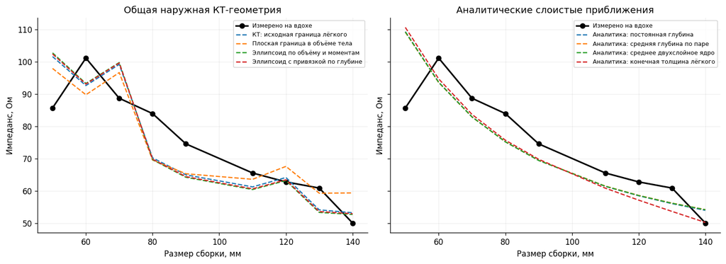

**Рисунок 3. Подгонка реального размерного ряда.** Чёрные точки — измеренные уровни вдоха, цветные линии — прогнозы при найденных сопротивлениях. **Слева все четыре модели используют пространственную PEM; справа все четыре приближения используют аналитические точечные электроды. CEM здесь не показана.** У аналитических приближений импеданс монотонно уменьшается с размером, тогда как измеренный уровень 60 мм выше уровня 50 мм. Пространственные кривые также воспроизводят не все перепады ряда. Причина расхождений этим рисунком не разделяется: в ней могут участвовать модель, установка контактов и межзаписная изменчивость. Все девять точек использованы при подгонке; это проверка воспроизведения наблюдений, а не независимый прогноз. Семь из восьми моделей достигают верхней границы $\rho_2$. Внутренний минимум у плоской границы внутри КТ-тела не делает её предпочтительной: в синтетическом опыте она имеет большую ошибку свойств тканей. Ранжирование только по остатку смешивает геометрическую адекватность и возможность компенсации её ошибки параметрами. Точечный контакт остаётся приближением конечных электродов. Далее проверяются исключения размеров и влияние этого электродного приближения.

## 6. Условный прогноз и устойчивость экспериментальных оценок

Девять раз исключается один размер: сопротивления определяются по восьми, а импеданс исключённого размера вычисляется без его участия в этой подгонке. Среднеквадратичная ошибка девяти таких прогнозов характеризует условную проверку при фиксированной прежней позе. Дополнительно каждый измеренный импеданс по очереди изменяется на ±1%, остальные сохраняются: 18 сценариев на модель. Максимальный сдвиг оценки относительно невозмущённой подгонки не является ошибкой относительно истинного сопротивления или доверительным интервалом. Один процент — заданное испытательное возмущение, не измеренный шум.

Дополнительный локальный показатель — число обусловленности $\kappa_2(J)=s_{\max}/s_{\min}$ матрицы $J_{Lj}=\partial Z_L/\partial x_j$, где $s$ — сингулярные числа. Столбцы $J$ выражены в омах и описывают отклик на относительные изменения двух параметров; используются все девять размеров с равными весами. Большое $\kappa$ указывает, что одна комбинация параметров определяется заметно слабее другой. Чувствительность только к $\rho_2$ недостаточна: её отклик может быть похож на отклик от $\rho_1$, что затрудняет разделение. Меньшее $\kappa$ полезно при верной прямой модели, но не устраняет смещения из-за неверной геометрии. У плоской границы внутри тела оно ниже, чем у исходной КТ, хотя синтетическая ошибка параметров больше. Эти числа не являются процентной погрешностью или доверительным интервалом. Для граничной оценки допустимы изменения не во всех направлениях, поэтому матрицу $J$ нельзя автоматически превращать в обычный симметричный интервал неопределённости.

| Модель | Условный прогноз, Ом | Мин. ρ₁, Ом·м | Макс. ρ₁, Ом·м | Мин. ρ₂, Ом·м | Макс. ρ₂, Ом·м |
| --- | --- | --- | --- | --- | --- |
| КТ: исходная граница лёгкого | 11,076 | 5,9098 | 6,3012 | 24,074 | 24,074 |
| Плоская граница в объёме тела | 12,07 | 5,4334 | 6,3263 | 12,125 | 21,075 |
| Эллипсоид по объёму и моментам | 11,661 | 6,0394 | 6,4611 | 24,074 | 24,074 |
| Эллипсоид с привязкой по глубине | 11,489 | 5,9945 | 6,4068 | 24,074 | 24,074 |
| Аналитика: постоянная глубина | 13,056 | 6,0003 | 6,809 | 19,028 | 24,074 |
| Аналитика: средняя глубина по паре | 13,063 | 5,9823 | 6,8066 | 18,946 | 24,074 |
| Аналитика: среднее двухслойное ядро | 13,085 | 5,9966 | 6,8168 | 18,902 | 24,074 |
| Аналитика: конечная толщина лёгкого | 12,819 | 6,0682 | 6,6935 | 24,074 | 24,074 |

| Модель | Макс. сдвиг ρ₁ при ±1%, % | Макс. сдвиг ρ₂ при ±1%, % |
| --- | --- | --- |
| КТ: исходная граница лёгкого | 0,19556 | 0 |
| Плоская граница в объёме тела | 0,41484 | 1,3036 |
| Эллипсоид по объёму и моментам | 0,194 | 0 |
| Эллипсоид с привязкой по глубине | 0,19449 | 0 |
| Аналитика: постоянная глубина | 0,21161 | 0 |
| Аналитика: средняя глубина по паре | 0,21342 | 0 |
| Аналитика: среднее двухслойное ядро | 0,21238 | 0 |
| Аналитика: конечная толщина лёгкого | 0,21208 | 0 |

| Модель | Число обусловленности, безразм. | Наименьшее сингулярное число, Ом |
| --- | --- | --- |
| КТ: исходная граница лёгкого | 31,714 | 6,7895 |
| Плоская граница в объёме тела | 7,9513 | 24,842 |
| Эллипсоид по объёму и моментам | 38,59 | 5,6415 |
| Эллипсоид с привязкой по глубине | 36,484 | 5,9461 |
| Аналитика: постоянная глубина | 14,274 | 14,538 |
| Аналитика: средняя глубина по паре | 13,078 | 15,787 |
| Аналитика: среднее двухслойное ядро | 13,516 | 15,324 |
| Аналитика: конечная толщина лёгкого | 17,379 | 11,966 |

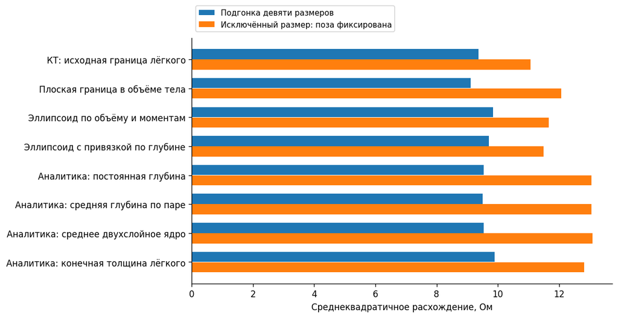

**Рисунок 4. Остаток подгонки и условная ошибка прогноза.** Для каждой модели сопоставлены ошибка по всем данным после их использования и ошибка исключаемых по одному размеров. Все восемь строк относятся к точечным электродам: пространственной PEM либо аналитическим точкам. Для CEM аналогичная проверка исключённых размеров в 20.14 не выполнялась. Меньший второй столбец предпочтителен по данному критерию. Он проверяет согласованность формы размерного ряда, но не измеряет точность $\rho_1,\rho_2$ у испытуемого. Поза ранее использовала весь ряд, поэтому эти столбцы не следует представлять как независимую внешнюю валидацию. Сохранение $\rho_2$ на одной границе при исключениях или возмущениях может давать искусственно малую изменчивость параметра. Оно не означает, что параметр точно измерен. Следующий шаг — отделять устойчивость, создаваемую данными, от устойчивости из-за ограничения, а для независимого прогноза повторить всю подгонку, включая позу, без проверочного измерения.

Более узкий лёгочный диапазон проверяет конкретное решение о включении частотного ориентира Gabriel в рабочую область. Оценки всех восьми моделей совпадают при приведённой в таблицах точности. Это указывает на нечувствительность к данной нижней границе в настоящем опыте. Такой результат не устанавливает достаточность верхней границы или универсальность литературного диапазона.

**Проверка более узкого лёгочного диапазона 14,2857–24,0741 Ом·м:**

| Модель | ρ₁, Ом·м | ρ₂, Ом·м | Остаток, Ом | ρ₂ на границе |
| --- | --- | --- | --- | --- |
| КТ: исходная граница лёгкого | 6,0393 | 24,074 | 9,3622 | Да |
| Плоская граница в объёме тела | 5,7665 | 16,019 | 9,1188 | Нет |
| Эллипсоид по объёму и моментам | 6,1751 | 24,074 | 9,848 | Да |
| Эллипсоид с привязкой по глубине | 6,1284 | 24,074 | 9,7063 | Да |
| Аналитика: постоянная глубина | 6,1163 | 24,074 | 9,5461 | Да |
| Аналитика: средняя глубина по паре | 6,1007 | 24,074 | 9,5033 | Да |
| Аналитика: среднее двухслойное ядро | 6,1141 | 24,074 | 9,5332 | Да |
| Аналитика: конечная толщина лёгкого | 6,1697 | 24,074 | 9,9 | Да |

## 7. Точечные и конечные электроды на исходной КТ-геометрии

### 7.1. Что физически означает расчёт CEM

В этой проверке сохранена исходная двухтканная КТ-маска. У каждого из четырёх электродов имеется контактная площадка $E_l$, составленная из треугольников наружной поверхности тела. Металл электрода считается идеальным проводником: его потенциал $U_l$ одинаков по всей площадке. Потенциал ткани под ним $u$ может изменяться из-за конечного сопротивления контакта.

Связь потенциалов записывается как

$$U_l-u=z_c j_{\mathrm{in}},\qquad \int_{E_l}j_{\mathrm{in}}\,dS=I_l,$$

где $j_{\mathrm{in}}$ — плотность тока, направленного от электрода внутрь тела, А/м²; $z_c$ — удельное поверхностное сопротивление, Ом·м². При внешней нормали $n$ используется $j_{\mathrm{in}}=\sigma\partial u/\partial n$. На токовых площадках интегральные токи равны $+I$ и $-I$; на измерительных площадках — нулю. Нулевой суммарный ток измерительного электрода не требует нулевой плотности тока в каждой его точке: проводящая площадка может перераспределять ток локально. Вне электродов наружная поверхность изолирована.

В результате измеряемое напряжение равно $U_{V+}-U_{V-}$, а не потенциалу одного узла ткани. CEM заново определяет поле совместно с потенциалами электродов; усреднение ранее рассчитанного PEM-поля такого решения не заменяет. Два тканевых сопротивления $\rho_1,\rho_2$ имеют единицы Ом·м и остаются отдельными от контактного параметра $z_c$ в Ом·м².

### 7.2. Какие параметры контактов фактически использованы

| Параметр | Принятое или реализованное значение | Происхождение и смысл |
| --- | --- | --- |
| Число электродов | 4 в каждом из 9 отдельных монтажей | Два токовых и два измерительных |
| Номинальная площадь | 70,6858 мм² | Целевой параметр построения одной площадки |
| Фактическая площадь на сетке | 70,8567–78,1577 мм² | Диапазон по 36 площадкам из таблицы контактов 20.13 |
| Поверхностное сопротивление контакта | 1,59155·10⁻⁴ Ом·м² | Одно фиксированное значение для всех площадок; не подбиралось по этим измерениям |
| Смещение центроида от запрошенной точки, максимум | 4,0024 мм | Дискретное построение площадки; не измеренная ошибка наклейки |
| Расстояние узла PEM до центроида CEM, максимум | 3,0717 мм | Дополнительное геометрическое различие точечной и площадной постановок |
| Нормировка тока | 1 А | Линейная нормировка решателя; фактический ток прибора этим числом не устанавливается |

Площадки и контактный параметр перенесены из сохранённой модели 20.13. Их размеры описывают **реализованную сеточную геометрию**, а не новое измерение электродов на коже. Узел PEM расположен вблизи центроида соответствующей CEM-площадки, но не обязан совпадать с ним. Поэтому сравнение включает конечную площадь, контактный закон и дискретную замену площадки одним узлом. Эти вклады по отдельности здесь не разделены.

### 7.3. Что оставалось фиксированным и что подбиралось

Для обеих подгонок одинаковы КТ-маски и объёмная сетка, прежняя поза сборки, девять экспериментальных уровней вдоха, равные веса размеров и литературные границы обоих сопротивлений. Подбираются только $\rho_1$ и $\rho_2$. Геометрия лёгкого, положение электродов и $z_c$ в этой проверке не оптимизируются.

PEM-подгонка использует библиотеку точечных откликов. CEM-подгонка напрямую решает поле при каждой новой паре сопротивлений и использует сопряжённую задачу для производных. Для CEM выполнены три запуска из разных начальных пар: результата PEM, центра логарифмической области и частотных ориентиров мышцы и наполненного воздухом лёгкого. Это три проверки поиска по одному экспериментальному ряду, а не три независимых измерения.

### 7.4. Полученные сопротивления и остаток

| Показатель | Исходная КТ + точечные PEM | Исходная КТ + конечные CEM |
| --- | --- | --- |
| ρ₁, Ом·м | 6,03932 | 5,74486 |
| ρ₂, Ом·м | 24,07407 | 24,07407 |
| Среднеквадратичный остаток по 9 размерам, Ом | 9,3622 | 8,1509 |
| Положение ρ₂ в рабочей области | Верхняя граница | Верхняя граница |

При замене точечных электродов площадками и повторной подгонке остаток уменьшился на **1,2113 Ом**, или **12,94%** относительно PEM-подгонки. Оценка ρ₁ изменилась на **-4,88%**. Оценка ρ₂ осталась на верхней границе. Ни одна из этих пар не является независимо измеренными сопротивлениями тканей. В ходе трёх запусков CEM рассчитано **32** различных наборов параметров; для каждого решены девять монтажей с прямым и сопряжённым возбуждением. Результаты трёх стартов приведены ниже. Их согласие подтверждает воспроизводимость найденного минимума, но не глобальную единственность.

| Старт | ρ₁, Ом·м | ρ₂, Ом·м | Остаток CEM, Ом | Критерий остановки выполнен |
| --- | --- | --- | --- | --- |
| 1 | 5,7449 | 24,074 | 8,1509 | Да |
| 2 | 5,7449 | 24,074 | 8,1509 | Да |
| 3 | 5,7449 | 24,074 | 8,1509 | Да |

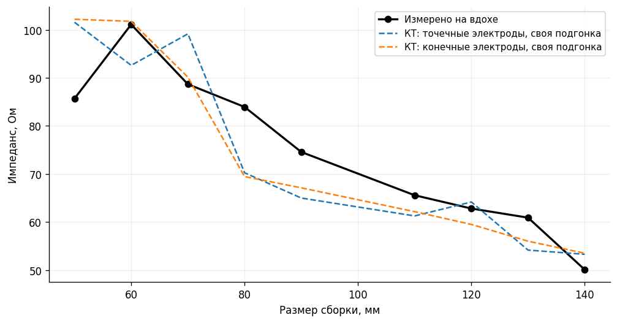

После CEM-подгонки: **ρ₁=5.74486 Ом·м**, **ρ₂=24.07407 Ом·м**, остаток **8.1509 Ом**. Для точечных электродов остаток равен **9.3622 Ом**.

**Рисунок 5. Влияние описания контактов на подгонку исходной КТ-модели.** Показаны один измеренный ряд и две подгонки с разными электродными условиями. Каждая кривая использует свою найденную пару сопротивлений. Поэтому разность кривых после подгонки не равна прямому контактному эффекту при фиксированных сопротивлениях. По рисунку и таблице следует оценивать остаток и сдвиг обоих параметров. Даже уменьшение остатка CEM не устанавливает их истинные значения. Контактное сопротивление отдельно не подбиралось, а точность позы этим сравнением не подтверждается. Если вывод об упрощённой геометрии зависит от контактов, следующий геометрический кандидат необходимо проверять при согласованной конечной электродной постановке.

### 7.5. Результат по каждому размеру сборки

Таблица позволяет установить, на каких размерах изменилось совпадение с измерениями. Все значения импеданса и остатка выражены в омах; $r=Z_{\mathrm{модель}}-Z_{\mathrm{измерено}}$. Положительный остаток означает завышение импеданса. В каждой колонке модели используется своя найденная пара сопротивлений из раздела 7.4.

| L, мм | Измерено, Ом | КТ/PEM, Ом | r PEM, Ом | КТ/CEM, Ом | r CEM, Ом |
| --- | --- | --- | --- | --- | --- |
| 50 | 85,689 | 101,563 | 15,874 | 102,185 | 16,496 |
| 60 | 101,102 | 92,604 | -8,498 | 101,755 | 0,653 |
| 70 | 88,678 | 99,150 | 10,472 | 90,141 | 1,463 |
| 80 | 83,943 | 70,260 | -13,683 | 69,470 | -14,473 |
| 90 | 74,580 | 65,005 | -9,575 | 67,125 | -7,455 |
| 110 | 65,581 | 61,283 | -4,298 | 62,170 | -3,411 |
| 120 | 62,821 | 64,182 | 1,361 | 59,515 | -3,306 |
| 130 | 60,923 | 54,177 | -6,746 | 56,028 | -4,895 |
| 140 | 50,103 | 53,300 | 3,197 | 53,518 | 3,415 |

Уменьшение общего остатка не означает улучшения каждого размера. Особенно заметно улучшение при 60 и 70 мм. При 50, 80, 120 и 140 мм абсолютный остаток CEM больше, чем PEM после соответствующих подгонок. Это объясняет, почему одного общего числа недостаточно для оценки формы размерного ряда. Разности между колонками PEM и CEM не следует интерпретировать как чистую поправку от площади: сопротивления в двух подгонках различаются.

### 7.6. Что установлено и что пока не проверено

**Результат данного расчёта:** на исходной КТ-геометрии описание электродов существенно влияет на остаток и оценку $\rho_1$. Учёт конечных площадок уменьшает остаток по всему ряду, однако не устраняет граничную оценку $\rho_2$. Поза и контактный параметр остаются принятыми условиями; точность оценки сопротивлений у испытуемого этим сопоставлением не установлена.

**Область переноса вывода:** CEM здесь проверена только на исходной КТ-маске. Для сокращённых пространственных геометрий в 20.14 нет ни CEM-инверсии, ни CEM-проверки исключённых размеров, ни CEM-оценки сдвигов при ±1%. Следовательно, результаты разделов 4–6 нельзя приписывать конечным электродам, а уменьшение остатка исходной КТ/CEM — считать доказательством преимущества эллипсоида или другого геометрического упрощения. Для такого вывода нужен отдельный опыт с согласованными CEM-условиями у сравниваемых геометрий.

## 8. Итог двух проверок и следующий геометрический шаг

**Результат моделирования: устойчивого победителя среди упрощений нет.** На 49 сочетаниях привязанный эллипсоид уменьшает медиану абсолютной ошибки $\rho_2$ с 26,04% у прежней аналитики до 16,28%, но увеличивает максимум с 96,33% до 112,54%. Для 25 внутренних сочетаний медиана составляет 22,00% против 20,52% у прежней аналитики: преимущество по этому показателю исчезает. Поэтому итог зависит от выбранных случаев и влияния границ. Одновременное улучшение обоих параметров получено в 15 из 49 случаев для привязанного эллипсоида и в 20 из 49 для усреднения двухслойного ядра; ни один из этих результатов не обосновывает универсальную замену прежней модели.

**Малый остаток не гарантирует точность тканевых параметров.** В одном синтетическом случае заданы $\rho_1=1{,}37741$, $\rho_2=9{,}74127$ Ом·м. Привязанный эллипсоид восстанавливает 1,38193 и 18,81491 Ом·м при остатке всего 0,05970 Ом. Ошибка $\rho_1$ составляет +0,328%, а $\rho_2$ — +93,15%. Обе оценки находятся в рабочей литературной области. Это конкретный пример того, как почти совпавший размерный ряд скрывает ошибку одного материала: небольшое влияние глубокой области и компенсация геометрии параметрами позволяют сохранить близкие импедансы.

**Результат обработки измерений:** семь из восьми основных подгонок и дополнительная CEM-подгонка достигают верхней границы $\rho_2$. CEM уменьшает остаток исходной КТ-модели с 9,3622 до 8,1509 Ом, одновременно изменяя $\rho_1$ с 6,0393 до 5,7449 Ом·м. Условная ошибка прогноза исключённых размеров для КТ/PEM составляет 11,08 Ом, для привязанного эллипсоида — 11,49 Ом, для прежней аналитики — 13,06 Ом. Эти различия описывают данный ряд при прежней позе; они не определяют истинные сопротивления. Нулевой сдвиг $\rho_2$ в большинстве испытаний ±1% объясняется удержанием на границе, а не исключительной точностью.

Синтетический тест оценивает контролируемую потерю информации при сокращении достоверной анатомии. Он показывает, что уменьшение типичной ошибки и уменьшение наихудшей ошибки могут вести к разным решениям. Ограничение параметров литературной областью не устраняет ошибки геометрии; оно меняет доступный способ её компенсации. Почти точное восстановление исходной КТ-моделью является самоконтролем согласованного численного оператора.

Экспериментальный тест выявляет согласованность моделей с реальными импедансами, граничные оценки и зависимость от исключения размеров. Он не даёт процент истинной ошибки сопротивления. Поэтому преимущество нового упрощения должно одновременно опираться на контролируемые синтетические ошибки, условный прогноз измерений и анализ контактов. Одного малого остатка, одного минимума внутри литературной области или одной медианы синтетической ошибки недостаточно для признания модели более точной.

Следующий кандидат следует строить по локальной КТ-геометрии под сборкой: сначала сохранить продольный профиль ближней поверхности лёгкого, затем проверить поперечную кривизну и положение конечного края. Эти признаки нужно вводить раздельно, чтобы оценить вклад каждого в оба утверждённых теста. Поддиафрагмальная область сохраняет $\rho_1$. Новая локальная поверхность, метод граничных элементов (BEM) или иной поверхностный решатель в данном этапе ещё не реализованы. Выбор формы и выбор численного способа расчёта поля являются отдельными решениями.

## 9. Воспроизводимость и ограничения

Единая MATLAB-точка входа `run_pipeline` содержит профили `geometry_validation`, `geometry_validation_cem` и проверочный профиль `geometry_validation_derivative_qc`. Подготовка плана и инверсия выполняются `tools/geometry_validation_tests.py`; команды приведены в документации расчётных стадий. Ноутбук строит представление сохранённых результатов и не запускает FEM при обычном выполнении ячеек. Проверка производных CEM выполнена центральными конечными разностями для размеров 50 и 140 мм, обоих параметров и двух шагов по логарифму внутри рабочей области. Максимальное относительное расхождение — 2,90·10⁻⁶. Это проверка вычисления производных, а не точности анатомии. Контрольные суммы связывают исходные библиотеки, литературную таблицу, манифест измерений и выполненный расчёт.

Проверены одна анатомия, одна сетка, одно состояние дыхания и один прежний кандидат позы. Литературные диапазоны являются рабочим переносом сведений о тканях на эффективную двухтканную постановку. Сходимость сетки, неизвестная фактическая установка электродов, анизотропия и отдельное контактное сопротивление не оцениваются этим набором. Клиническая точность и оптимальная пара сборок не установлены. Индивидуальные результаты остаются локальными; новый ноутбук не является разрешением на публикацию анатомии или сигналов.